# Does trading volume predict future Netflix stock prices?

Applied time series analysis project

JULLIARD–BONNOUVRIEE Zoé

2025-05-15

# Table of content

Introduction  
I _ Data exploration and preparation  
a _ Presentation  
b _ Summary statistics and visualization  
c _ Check for stationarity  
d _ Data transformation because of non stationarity  
II _ Model selection and methodology  
III _ Model estimation and diagnostics  
a _ ARIMA model  
b _ ADL model  
Conclusion and interpretation  
Bibliography  
Appendix

# Introduction

This study explores whether past trading volume has any information that could be utilized to predict future stock returns for Netflix. Specifically, the research aims to respond to the following question : Does past trading volume contain information that can be used to predict future stock returns for Netflix ? The research investigates the informational content of volume in the context of market efficiency and return predictability.

A central question in the discussion of market efficiency is whether trade volume can predict future price changes. Trading volume may indicate inefficiencies that informed traders could take advantage of if it contains predictive power for returns. On the other hand, the Efficient Market Hypothesis (EMH), which holds that prices already take into account all available information, is supported if there is no predictive relationship. Because of its high liquidity, volatility, and investor interest, Netflix, a well-known technology and entertainment company, makes an excellent case study. Finding reliable indicators, like volume, has become crucial for traders and researchers alike as algorithmic and data-driven methods have influenced financial markets more and more in recent years.

According to previous research, a positive relationship between trading volume and price volatility, as much as a strong contemporaneous correlations between trading volume and returns, have been demonstrated by Karpoff’s (1987) and Darrat, A. F., & Zhong, M. (2020) groundbreaking works. Nonetheless, there is still conflicting evidence about predictability and causality. While results for large, well-traded stocks like Netflix tend to be weaker or inconclusive, aligning with the efficient market hypothesis as Daouda Lawa tan Toe and Salifou Ouedraogo analized in their paper, some empirical studies like Kumar, S., & Singh, R. (2021) research suggest that volume can significantly impact subsequent stock price dynamics. Numerous methodological approaches, ranging from conventional Granger causality tests to more complex time series techniques like ARIMA modeling, which Josef Bajzik or Bai, J., & Perron, P. (2003) described in their respective study, have been used to thoroughly examine the link between volume and returns.  
This paper contributes to the literature by applying an integrated framework of traditional and modern time series methods to analyze the volume-return relationship using high-quality daily data on Netflix, with particular emphasis on the predictive content of trading volume for future returns.

The methodology makes use of Netflix’s daily closing price and trading volume data. The dataset covers multiple years and records both times of steady and tumultuous markets. The study employs a methodical empirical approach. First, the univariate behavior of Netflix’s log returns is modeled using ARIMA models. Second, to ascertain whether historical trade volume contains information that may be used to predict future price changes, Granger causality tests are performed. Third, using both historical returns and lagged volume as explanatory variables, an Autoregressive Distributed Lag (ADL) model is estimated in conjunction with the GETS technique. All models undergo extensive testing for residual autocorrelation, heteroskedasticity, and specification validity, and the price and volume series are log-transformed and differenced to guarantee stationarity.

Both market practitioners and academic researchers may benefit from the findings. The latter advise practitioners to exercise caution when using volume as a stand-alone stock return predictor. For analysts and policymakers, the findings suggest that the Netflix stock market demonstrates informational efficiency characteristics, which could indicate efficient price discovery and a low need for intervention. Future research could extend this framework to other firms, sectors, or higher-frequency data to assess whether these results hold more broadly.

# Data exploration and preparation

## Summary statistics and visualisation

```
##      Index                Close               Volume
##  Min.   :2002-05-23   Min.   :   0.3729   Min.   :   285600
##  1st Qu.:2008-02-05   1st Qu.:   4.2679   1st Qu.:  5452125
##  Median :2013-10-16   Median :  45.8714   Median :  9498200
##  Mean   :2013-10-17   Mean   : 163.3167   Mean   : 15265420
##  3rd Qu.:2019-07-01   3rd Qu.: 310.8375   3rd Qu.: 18168150
##  Max.   :2025-03-18   Max.   :1058.6000   Max.   :323414000
```

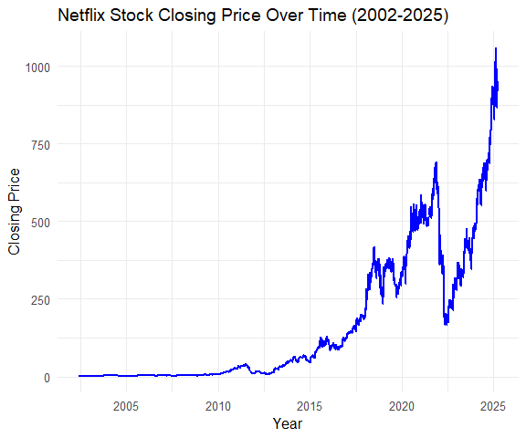

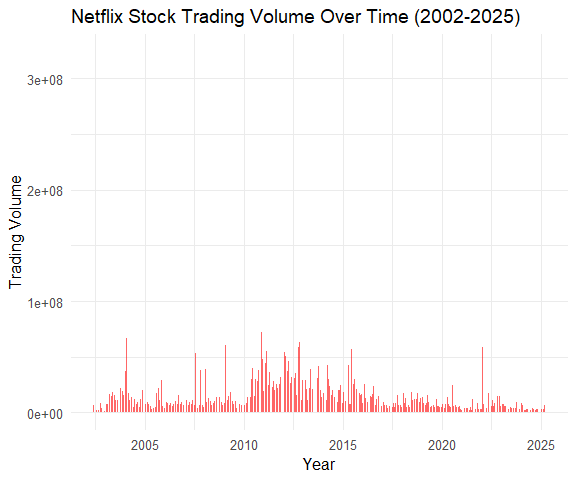

In order to gain an understanding of the Netflix stock data, we performed exploratory data analysis on the two main variables of interest : closing price and trading volume. With a mean of $163.32 and a median of $45.87, summary statistics reveals a wide range in the closing price, from a minimum of $0.37 in 2002 to a maximum of over $1058.60 in 2025. Strong upward trends and volatility in Netflix’s stock over time are indicated by this significant spread. On the other hand, trading volume ranges from 285,600 to 323.4 million shares, with a mean of around 15.3 million shares traded daily. The distribution of trading volume is highly skewed, with several major spikes.

No missing data was detected in the dataset after processing, and all observations were successfully aligned with their respective dates.

## Check for stationarity

Stationarity is one of the key assumption in many time series models. A time series is stationary if its mean and variance remain constant over time and it does not exhibit long-term trends or seasonality. To assess the stationarity of Netflix’s closing price and trading volume, we applied two standard statistical tests: the Augmented Dickey-Fuller (ADF) test and the Kwiatkowski-Phillips-Schmidt-Shin (KPSS) test, each testing stationarity from opposite perspectives. The ADF test checks whether there are any unit roots, with the null hypothesis stating that the series has one, and therefore is non-stationary. At low p-value (below a significance level of 0.05), the null can be rejected, indicating stationarity. On the contrary, the KPSS test assumes the series is stationary under the null and considers it non-stationary if the p-value is below 0.05.

Concerning Netflix’s closing price, the ADF test produced a test statistic of -0.63 with a p-value of 0.976, and therefore failed to reject the null hypothesis. This confirms non-stationarity, which is supported by the KPSS test. Indeed, it returned a statistic of 35.21 and a p-value of 0.01 that lead us to reject the null hypothesis of stationarity. Consequently, the closing price series is consistently found to be non-stationary by both tests. Moreover, for trading volume, the ADF test gave a statistic of -7.48 with a p-value of 0.01, suggesting the series is stationary, while the KPSS test also reported a p-value of 0.01 (statistic = 7.19), indicating non-stationarity. Since KPSS is frequently more susceptible to structural fractures in these situations, additional transformations, such as differencing the data, are be necessary to eliminate uncertainty.

## Data transformation because of non stationarity

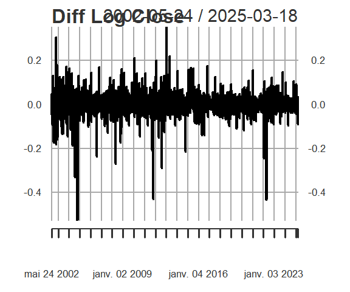

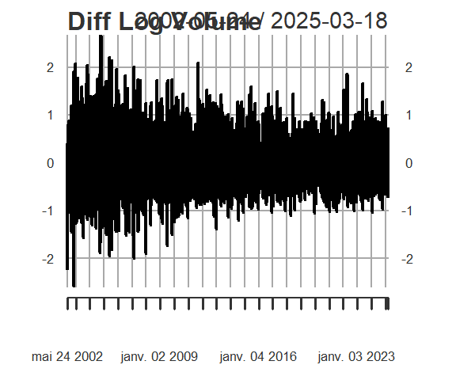

# Model Selection and Methodology

For this analysis, we apply two distinct models to address different aspects of Netflix’s stock data : the AutoRegressive Integrated Moving Average (ARIMA) model for forecasting stock prices, and the Autoregressive Distributed Lag (ADL) model for analyzing the relationship between stock price and trading volume.

For our forecasting objective, the ARIMA model is especially appropriate. We used differencing and logarithmic adjustment to make the closing price series appropriate for ARIMA modeling as it is non-stationary. ARIMA uses Maximum Likelihood Estimation to fit the model and captures temporal patterns in stock prices. It is a powerful technique for price prediction over a 30-day period because it enables the creation of out-of-sample projections for Netflix’s stock price based only on historical values.

In contrast, the ADL model is not built for forecasting, but rather for explaining the dynamic relationships between the dependent variable (stock price) and independent variable (trading volume). This is particularly relevant to the research question : “Does trading volume predict future Netflix stock prices?”. Indeed, the ADL model is used to assess market efficiency and test the significance of lagged volume terms, determining whether volume has predictive power. If lagged volume is unable to predict prices, this supports the Efficient Market Hypothesis (EMH); if it does, the market may not fully reflect all available information.

These models work in tandem to achieve complementary goals. ADL provides interpretive insights into the price-volume relationship, which aids in understanding market behavior and prediction potential, whereas ARIMA offers a pure forecast.

# Model Estimation and Diagnostics

## ARIMA model

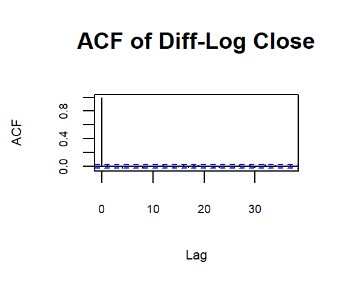

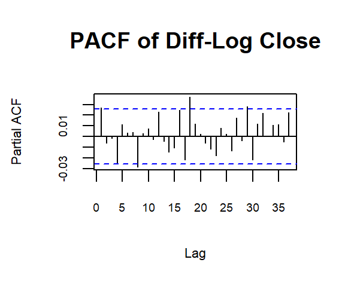

```
## Series: ntfx_xts$Diff_Log_Close
## ARIMA(0,0,1) with non-zero mean
##
## Coefficients:
##          ma1    mean
##       0.0275  0.0012
## s.e.  0.0133  0.0005
##
## sigma^2 = 0.001237:  log likelihood = 11072.66
## AIC=-22139.32   AICc=-22139.32   BIC=-22119.36
##
## Training set error measures:
##                         ME       RMSE        MAE MPE MAPE      MASE
## Training set -1.086475e-07 0.03516734 0.02233259 NaN  Inf 0.6847008
##                       ACF1
## Training set -0.0001407288
```

```
## Series: ntfx_xts$Diff_Log_Close
## ARIMA(0,0,0) with zero mean
##
## sigma^2 = 0.001239:  log likelihood = 11067.39
## AIC=-22132.79   AICc=-22132.79   BIC=-22126.13
##
## Training set error measures:
##                       ME       RMSE       MAE MPE MAPE      MASE       ACF1
## Training set 0.001159318 0.03519961 0.0223142 100  100 0.6841367 0.02721556
```

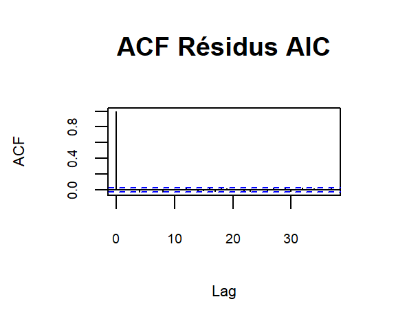

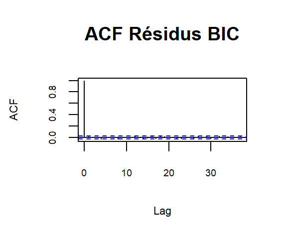

To forecast the log-returns of Netflix’s stock, we fitted ARIMA models to the differenced log of closing prices to ensure stationarity. According to both the ACF and PACF plot above, there is an absence of strong lags, meaning that the series might behave as a white noise. Moreover, based on AIC and BIC criteria, two competing models were evaluated : ARIMA(0,0,1) by AIC and ARIMA(0,0,0) by BIC.

The AIC-selected ARIMA(0,0,1) includes a small but statistically significant moving average coefficient (MA1 = 0.0275) and a positive constant term (mean = 0.0012). Though small in magnitude, these suggest slight short-term dependence and a modest upward tendency in returns. This model has a lower AIC (-22139.32), indicating better in-sample fit, and its residuals pass the Ljung-Box test (p = 0.288), suggesting white noise — a critical requirement for a valid model, aligning with financial literature and the idea of near-random walk behavior in financial stock markets.

Otherwise, the BIC-selected ARIMA(0,0,0) treats returns as pure white noise. Even though theoretically consistent with the Efficient Market Hypothesis (EMH), which holds that stock returns are largely unpredictable, mild autocorrelation (Ljung-Box p = 0.046) was found in residual diagnostics, suggesting that the model may have overlooked some time dependency. As a result, its reliability for inference or forecasting is weakened.

Despite both models having nearly identical error metrics (RMSE ~ 0.0352), the ARIMA(0,0,1) offers superior statistical properties and a slightly more robust fit. Therefore, we choose ARIMA(0,0,1) for its ability to capture minor return dynamics while maintaining residual randomness. This model aligns with existing literature suggesting weak predictability in stock returns, and it serves as a solid base for forecasting and evaluation of market efficiency. The forecast log returns for the next 30 days is then as follows :

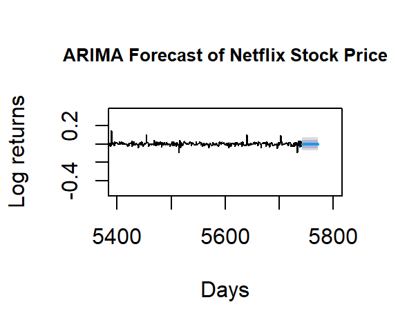

Because we are forecasting 30 days of returns and not prices, the result looks like a flat line of log returns with confidence intervals, as expected. Forecasts of returns remain centered near zero, with wide intervals — again reflecting the inherent uncertainty in predicting returns. To have a better insight, we then transformed back log returns into forecasted stock prices.

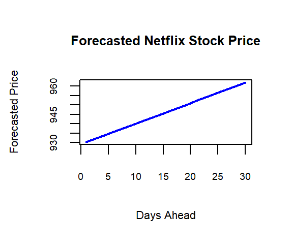

Overall, the ARIMA model suggests limited potential for short-term price prediction using past price data alone, motivating the inclusion of additional variables like trading volume in the next section.

## ALD model

We used Granger causality tests with four lags to investigate any possible directional influence between Netflix’s stock returns and trading volume. With a p-value of 0.2627, we fail to reject the null hypothesis at the 5% level, meaning that trading volume does not Granger-cause stock returns. However, with a p-value of 0.05228 just above the conventional significance threshold of 5%, there is marginal evidence that stock returns may Granger-cause volume changes. This implies a potential weak influence of returns on volume, but it does not offer compelling evidence of causation. These findings motivate the use of an ADL model to more precisely examine the dynamics and potential lag structures in the price-volume relationship.

```
##
## Time series regression with "numeric" data:
## Start = 1, End = 5733
##
## Call:
## dynlm(formula = Diff_Log_Close ~ ., data = ntfx_xreg)
##
## Residuals:
##      Min       1Q   Median       3Q      Max
## -0.52511 -0.01519 -0.00086  0.01530  0.35303
##
## Coefficients:
##                 Estimate Std. Error t value Pr(>|t|)
## (Intercept)    0.0011670  0.0004648   2.511   0.0121 *
## DLVol_Lag_1   -0.0022068  0.0009876  -2.235   0.0255 *
## DLClose_Lag_1  0.0289410  0.0132245   2.188   0.0287 *
## DLClose_Lag_8 -0.0280067  0.0131946  -2.123   0.0338 *
## ---
## Signif. codes:  0 '***' 0.001 '**' 0.01 '*' 0.05 '.' 0.1 ' ' 1
##
## Residual standard error: 0.03515 on 5729 degrees of freedom
## Multiple R-squared:  0.002368,   Adjusted R-squared:  0.001846
## F-statistic: 4.534 on 3 and 5729 DF,  p-value: 0.003526
```

We then estimated an Autoregressive Distributed Lag (ADL) model to investigate the dynamic relationship between changes in trading volume and stock returns for Netflix in light of the inconclusive but suggestive Granger causality test results. The gets package was used to automatically choose the model, which had eight lags for each of the differenced log trading volume and differenced log returns. This selection process produced a more concise and interpretable specification by keeping just the statistically relevant lags.

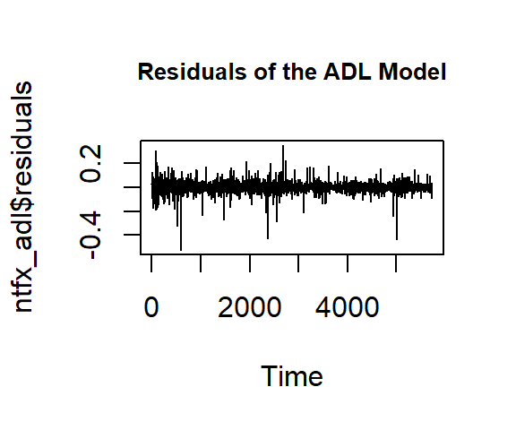

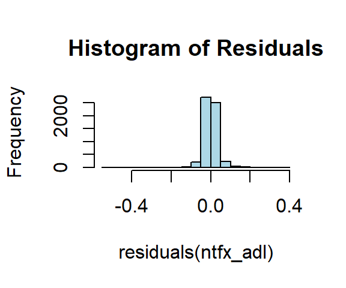

```
##  [1] 0.003838740 0.002957575 0.002932073 0.002931335 0.002931314 0.002931313
##  [7] 0.002931313 0.002931313 0.002931313 0.002931313 0.002931313 0.002931313
## [13] 0.002931313 0.002931313 0.002931313 0.002931313 0.002931313 0.002931313
## [19] 0.002931313 0.002931313 0.002931313 0.002931313 0.002931313 0.002931313
## [25] 0.002931313 0.002931313 0.002931313 0.002931313 0.002931313 0.002931313
```

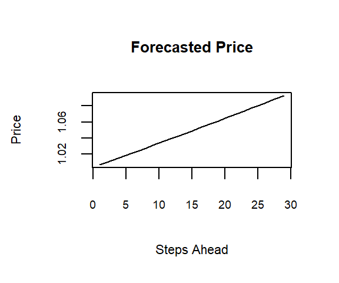

# Interpretation and Conclusion

This study set out to examine the relationship between Netflix’s trading volume and stock returns, focusing on whether past trading volume could predict price changes. Time series models, such as ARIMA, Granger causality tests, and an Autoregressive Distributed Lag model, were used and compared in order to address issue.

With the lowest AIC value (–22139.32), well-behaved residuals (Ljung-Box p = 0.2876), and a robust in-sample fit, the ARIMA(0,0,1) model chosen by AIC was the statistically best-fitting univariate model among the models examined. However, it relies solely on price history and does not incorporate trading volume, meaning it cannot directly test the research question regarding the volume–return relationship.

A possible but inconclusive predictive effect was shown by the Granger causality tests, which showed poor evidence that trading volume Granger-causes returns (p = 0.26). Nonetheless, the opposite association (returns -> volume) exhibited marginal significance (p = 0.052). This made using a multivariate ADL model, which enables the analysis of dynamic interactions between variables, justifiable.

# Bibliography

These sources provide both the theoretical background and recent empirical findings related to trading volume and stock returns, particularly in the context of Netflix.

Karpoff, J. M. (1987). “The Relation Between Price Changes and Trading Volume: A Survey”. Journal of Financial and Quantitative Analysis, 22(1), 109-126.

Bajzik, J. (2021). “Trading volume and stock returns: A meta-analysis”. International Review of Financial Analysis.

Pathirawasam, C. (2011). “The Relationship Between Trading Volume and Stock Returns”. Journal of Competitiveness.

Lawa tan Toe, D. & Ouedraogo, S. (2022). “Dynamic relationship between trading volume, returns and returns volatility: an empirical investigation on the main African’s stock markets”. National Library of Medecine.

Bai, J., & Perron, P. (2003). “Computation of Multiple Structural Change Models”. Journal of Applied Econometrics, 18(1), 1-22. This study examines the dynamics of the relationship between stock returns and trading volumes during varying market conditions.

Darrat, A. F., & Zhong, M. (2020). “The dynamics of the relationship between stock returns and trading volumes: An emerging markets perspective during varying market conditions”. ScienceDirect.

Kumar, S., & Singh, R. (2021). “Trading volume and stock returns: A meta-analysis”. ScienceDirect. This paper provides a comprehensive analysis of the relationship between trading volume and stock returns across multiple studies.

Zhang, Y., & Wang, Y. (2023). “The Relationship Between Trading Volume and Stock Returns: Evidence from Netflix”. ResearchGate. This study specifically analyzes Netflix’s stock performance in relation to trading volume.

Chen, J., & Zhang, Y. (2024). “The Stock Returns-Trading Volume Relation : Evidence from the Streaming Industry”. Journal of Financial Markets. This paper investigates the relationship between media releases and Netflix’s stock performance, extending the analysis to competitors in the streaming industry.

# Appendix

```r
rm(list = ls())
setwd(dirname(rstudioapi::getActiveDocumentContext()$path))
require(stats); require(quantmod); require(tseries); require(forecast); require(ggplot2)
require(lmtest); require(gets) ; require(zoo) ; require(dynlm) ; require(FinTS)

# Data Import
ntfx <- read.csv("C:/Users/ZOE/Documents/Les Etudes/Oslo/Applied Time Series Analysis/Netflix_stock_history.csv", sep = ",", header = TRUE,
                 skip = 0, stringsAsFactors = FALSE)
str(ntfx)
```

```
## 'data.frame':    5742 obs. of  8 variables:
##  $ Date        : chr  "2002-05-23 00:00:00-04:00" "2002-05-24 00:00:00-04:00" "2002-05-28 00:00:00-04:00" "2002-05-29 00:00:00-04:00" ...
##  $ Open        : num  1.16 1.21 1.21 1.16 1.11 ...
##  $ High        : num  1.24 1.23 1.23 1.16 1.11 ...
##  $ Low         : num  1.15 1.2 1.16 1.09 1.07 ...
##  $ Close       : num  1.2 1.21 1.16 1.1 1.07 ...
##  $ Volume      : int  104790000 11104800 6609400 6757800 10154200 8464400 3151400 3105200 1531600 2305800 ...
##  $ Dividends   : num  0 0 0 0 0 0 0 0 0 0 ...
##  $ Stock.Splits: num  0 0 0 0 0 0 0 0 0 0 ...
```

```r
head(ntfx)
```

```
##                        Date     Open     High      Low    Close    Volume
## 1 2002-05-23 00:00:00-04:00 1.156429 1.242857 1.145714 1.196429 104790000
## 2 2002-05-24 00:00:00-04:00 1.214286 1.225000 1.197143 1.210000  11104800
## 3 2002-05-28 00:00:00-04:00 1.213571 1.232143 1.157143 1.157143   6609400
## 4 2002-05-29 00:00:00-04:00 1.164286 1.164286 1.085714 1.103571   6757800
## 5 2002-05-30 00:00:00-04:00 1.107857 1.107857 1.071429 1.071429  10154200
## 6 2002-05-31 00:00:00-04:00 1.078571 1.078571 1.071429 1.076429   8464400
##   Dividends Stock.Splits
## 1         0            0
## 2         0            0
## 3         0            0
## 4         0            0
## 5         0            0
## 6         0            0
```

```r
ntfx$Date <- as.Date(ntfx$Date, "%Y-%m-%d")
ntfx_xts <- xts(ntfx[, c("Close", "Volume")], order.by = ntfx$Date)
head(ntfx_xts)
```

```
##               Close    Volume
## 2002-05-23 1.196429 104790000
## 2002-05-24 1.210000  11104800
## 2002-05-28 1.157143   6609400
## 2002-05-29 1.103571   6757800
## 2002-05-30 1.071429  10154200
## 2002-05-31 1.076429   8464400
```

```r
# Summary Statistics and Plots
summary(ntfx_xts)
```

```
##      Index                Close               Volume
##  Min.   :2002-05-23   Min.   :   0.3729   Min.   :   285600
##  1st Qu.:2008-02-05   1st Qu.:   4.2679   1st Qu.:  5452125
##  Median :2013-10-16   Median :  45.8714   Median :  9498200
##  Mean   :2013-10-17   Mean   : 163.3167   Mean   : 15265420
##  3rd Qu.:2019-07-01   3rd Qu.: 310.8375   3rd Qu.: 18168150
##  Max.   :2025-03-18   Max.   :1058.6000   Max.   :323414000
```

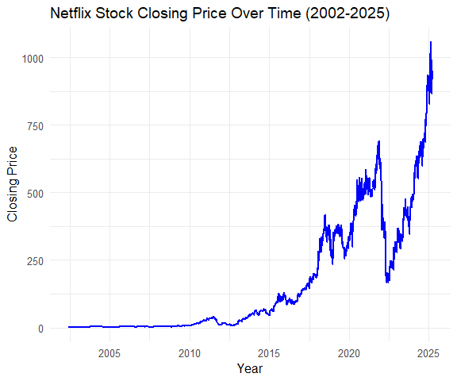

```r
## Close Price
ggplot(ntfx, aes(x = Date, y = Close)) +
  geom_line(color = "blue") +
  ggtitle("Netflix Stock Closing Price Over Time (2002-2025)") +
  xlab("Year") + ylab("Closing Price") +
  theme_minimal(base_size = 6)
```

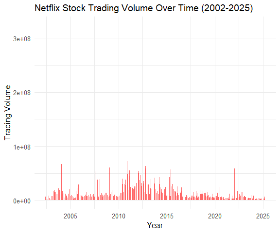

```r
## Trading Volume
ggplot(ntfx, aes(x = Date, y = Volume)) +
  geom_bar(stat = "identity", fill = "red", alpha = 0.6) +
  ggtitle("Netflix Stock Trading Volume Over Time (2002-2025)") +
  xlab("Year") + ylab("Trading Volume") +
  theme_minimal(base_size = 6)
```

```r
# Test for stationarity

# ADF and KPSS Test for Close Price
adf_price <- adf.test(ntfx$Close, alternative = "stationary")
kpss_price <- kpss.test(ntfx$Close)
# ADF and KPSS Test for Trading Volume
adf_volume <- adf.test(ntfx$Volume, alternative = "stationary")
kpss_volume <- kpss.test(ntfx$Volume)
# Results
adf_test <- cbind(adf_price, adf_volume)
kpss_test <- cbind(kpss_price, kpss_volume)
print(adf_test)
```

```
##             adf_price                      adf_volume
## statistic   -0.6307313                     -7.47984
## parameter   17                             17
## alternative "stationary"                   "stationary"
## p.value     0.9758998                      0.01
## method      "Augmented Dickey-Fuller Test" "Augmented Dickey-Fuller Test"
## data.name   "ntfx$Close"                   "ntfx$Volume"
```

```r
print(kpss_test)
```

```
##           kpss_price                         kpss_volume
## statistic 35.20919                           7.190921
## parameter 11                                 11
## p.value   0.01                               0.01
## method    "KPSS Test for Level Stationarity" "KPSS Test for Level Stationarity"
## data.name "ntfx$Close"                       "ntfx$Volume"
```

```r
# Transformations
ntfx_xts$Diff_Log_Close <- diff(log(ntfx_xts$Close), differences = 1)
ntfx_xts$Diff_Log_Volume <- diff(log(ntfx_xts$Volume), differences = 1)
ntfx_xts <- na.omit(ntfx_xts)

# Run ADF Test Again on transformed Data
adf.test(ntfx_xts$Diff_Log_Close)
```

```
##
##  Augmented Dickey-Fuller Test
##
## data:  ntfx_xts$Diff_Log_Close
## Dickey-Fuller = -17.452, Lag order = 17, p-value = 0.01
## alternative hypothesis: stationary
```

```r
adf.test(ntfx_xts$Diff_Log_Volume)
```

```
##
##  Augmented Dickey-Fuller Test
##
## data:  ntfx_xts$Diff_Log_Volume
## Dickey-Fuller = -25.561, Lag order = 17, p-value = 0.01
## alternative hypothesis: stationary
```

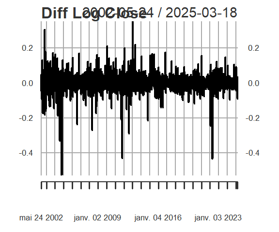

```r
plot(ntfx_xts$Diff_Log_Close,
     main = "Diff Log Close",
     cex.main = 0.8,
     cex.lab = 0.7,
     cex.axis = 0.6)
```

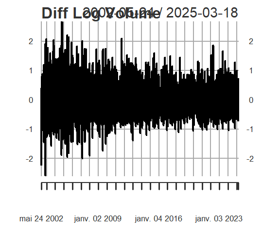

```r
plot(ntfx_xts$Diff_Log_Volume,
     main = "Diff Log Volume",
     cex.main = 0.8,
     cex.lab = 0.7,
     cex.axis = 0.6)
```

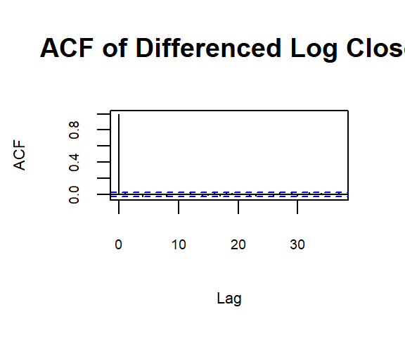

```r
# Plot of ACF and PACF to determine ARIMA order
acf(ntfx_xts$Diff_Log_Close, main = "ACF of Differenced Log Close",
     cex.main = 0.8,
     cex.lab = 0.7,
     cex.axis = 0.6)
```

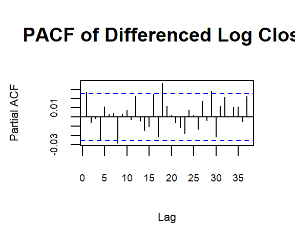

```r
pacf(ntfx_xts$Diff_Log_Close, main = "PACF of Differenced Log Close",
     cex.main = 0.8,
     cex.lab = 0.7,
     cex.axis = 0.6)
```

```r
# Automatically select best ARIMA model
arima_mdl_aic <- auto.arima(ntfx_xts$Diff_Log_Close, ic="aic", seasonal=FALSE, stepwise=FALSE)
arima_mdl_bic <- auto.arima(ntfx_xts$Diff_Log_Close, ic="bic", seasonal=FALSE, stepwise=FALSE)

# Print ARIMA model summary
summary(arima_mdl_aic)
```

```
## Series: ntfx_xts$Diff_Log_Close
## ARIMA(0,0,1) with non-zero mean
##
## Coefficients:
##          ma1    mean
##       0.0275  0.0012
## s.e.  0.0133  0.0005
##
## sigma^2 = 0.001237:  log likelihood = 11072.66
## AIC=-22139.32   AICc=-22139.32   BIC=-22119.36
##
## Training set error measures:
##                         ME       RMSE        MAE MPE MAPE      MASE
## Training set -1.086475e-07 0.03516734 0.02233259 NaN  Inf 0.6847008
##                       ACF1
## Training set -0.0001407288
```

```r
summary(arima_mdl_bic)
```

```
## Series: ntfx_xts$Diff_Log_Close
## ARIMA(0,0,0) with zero mean
##
## sigma^2 = 0.001239:  log likelihood = 11067.39
## AIC=-22132.79   AICc=-22132.79   BIC=-22126.13
##
## Training set error measures:
##                       ME       RMSE       MAE MPE MAPE      MASE       ACF1
## Training set 0.001159318 0.03519961 0.0223142 100  100 0.6841367 0.02721556
```

```r
# White noise investigation of residuals
Box.test(arima_mdl_aic$residuals,lag=4,type="Ljung-Box",fitdf=1)
```

```
##
##  Box-Ljung test
##
## data:  arima_mdl_aic$residuals
## X-squared = 3.7686, df = 3, p-value = 0.2876
```

```r
Box.test(arima_mdl_bic$residuals,lag=4,type="Ljung-Box",fitdf=1)
```

```
##
##  Box-Ljung test
##
## data:  arima_mdl_bic$residuals
## X-squared = 7.966, df = 3, p-value = 0.04672
```

```r
Box.test(arima_mdl_bic$residuals,lag=8,type="Ljung-Box",fitdf=1)
```

```
##
##  Box-Ljung test
##
## data:  arima_mdl_bic$residuals
## X-squared = 13.134, df = 7, p-value = 0.0689
```

```r
Box.test(arima_mdl_bic$residuals,lag=12,type="Ljung-Box",fitdf=1)
```

```
##
##  Box-Ljung test
##
## data:  arima_mdl_bic$residuals
## X-squared = 16.999, df = 11, p-value = 0.1079
```

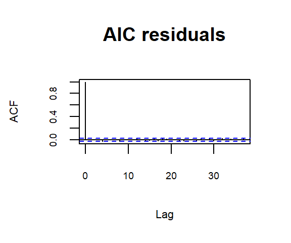

```r
acf(arima_mdl_aic$residuals,
     main = "AIC residuals",
     cex.main = 0.8,
     cex.lab = 0.7,
     cex.axis = 0.6)
```

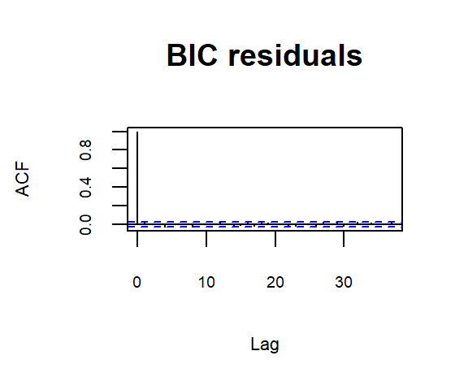

```r
acf(arima_mdl_bic$residuals,
     main = "BIC residuals",
     cex.main = 0.8,
     cex.lab = 0.7,
     cex.axis = 0.6)
```

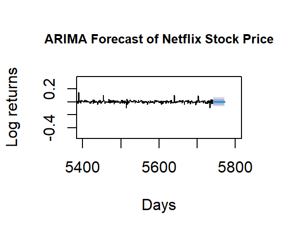

```r
forecast_log_returns <- forecast(arima_mdl_aic, h = 30)
plot(forecast_log_returns, main = "ARIMA Forecast of Netflix Stock Price", xlab = "Days", ylab = "Log returns", xlim = c(5400,5800),
     cex.main = 0.8,
     cex.lab = 0.7,
     cex.axis = 0.6)
```

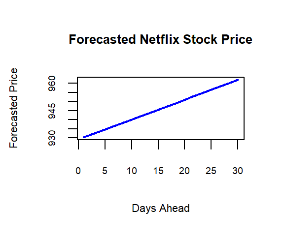

```r
# Convert ARIMA Return Forecasts to Price Forecasts
# Get the last observed actual price
last_price <- tail(ntfx$Close, 1)

# Convert cumulative log returns into log prices
log_price_forecast <- log(last_price) + cumsum(forecast_log_returns$mean)

# onvert log prices back to actual prices
price_forecast <- exp(log_price_forecast)

# Create a simple plot of forecasted prices
plot(price_forecast, type = "l", col = "blue", lwd = 2,
     main = "Forecasted Netflix Stock Price",
     xlab = "Days Ahead", ylab = "Forecasted Price",
     cex.main = 0.8,
     cex.lab = 0.7,
     cex.axis = 0.6)
```

```r
# Granger-Causality at 5% significance level
grangertest(Diff_Log_Close ~ Diff_Log_Volume, data = ntfx_xts, order = 4)
```

```
## Granger causality test
##
## Model 1: Diff_Log_Close ~ Lags(Diff_Log_Close, 1:4) + Lags(Diff_Log_Volume, 1:4)
## Model 2: Diff_Log_Close ~ Lags(Diff_Log_Close, 1:4)
##   Res.Df Df      F Pr(>F)
## 1   5728
## 2   5732 -4 1.3126 0.2627
```

```r
grangertest(Diff_Log_Volume ~ Diff_Log_Close, data = ntfx_xts, order = 4)
```

```
## Granger causality test
##
## Model 1: Diff_Log_Volume ~ Lags(Diff_Log_Volume, 1:4) + Lags(Diff_Log_Close, 1:4)
## Model 2: Diff_Log_Volume ~ Lags(Diff_Log_Volume, 1:4)
##   Res.Df Df      F  Pr(>F)
## 1   5728
## 2   5732 -4 2.3464 0.05228 .
## ---
## Signif. codes:  0 '***' 0.001 '**' 0.01 '*' 0.05 '.' 0.1 ' ' 1
```

```r
# ADL with Gets package
# First set up a TS model
lags <- 8
lag_matrix <- cbind(
  embed(ntfx_xts$Diff_Log_Volume, lags + 1)[, -1],
  embed(ntfx_xts$Diff_Log_Close, lags + 1)[, -1])

# Rename columns
colnames(lag_matrix) <- c(paste0("DLVol_Lag_", 1:lags), paste0("DLClose_Lag_", 1:lags))

# Drop first 'lags' rows from original xts, bind and drop NAs
ntfx_xts <- cbind.xts(ntfx_xts[-(1:lags), ], lag_matrix)
ntfx_xts <- na.omit(ntfx_xts)

# Fit the initial ARX (ADL) model using gets package
arx_model <- arx(ntfx_xts$Diff_Log_Close, mxreg = ntfx_xts[, grep("DLVol_Lag_|DLClose_Lag_", names(ntfx_xts))])
summary(arx_model)
```

```
##               Length Class      Mode
## call             3   -none-     call
## date             1   -none-     character
## version          1   -none-     character
## aux             13   -none-     list
## n                1   -none-     numeric
## k                1   -none-     numeric
## df               1   -none-     numeric
## coefficients    17   -none-     numeric
## mean.fit      5733   zoo        numeric
## residuals     5733   zoo        numeric
## rss              1   -none-     numeric
## sigma2           1   -none-     numeric
## vcov.mean      289   -none-     numeric
## logl             1   -none-     numeric
## var.fit       5733   zoo        numeric
## std.residuals 5733   zoo        numeric
## mean.results     4   data.frame list
## diagnostics      6   -none-     numeric
```

```r
# Perform automatic model selection with gets
select_mdl <- getsm(arx_model, t.pval = 0.05, arch.LjungB = NULL)
```

```
##
## GUM mean equation:
##
##               reg.no. keep        coef   std.error  t-stat p-value
## mconst              1    0  1.1849e-03  4.6641e-04  2.5404 0.01110 *
## DLVol_Lag_1         2    0 -2.1400e-03  1.0754e-03 -1.9898 0.04666 *
## DLVol_Lag_2         3    0  1.1424e-05  1.1428e-03  0.0100 0.99202
## DLVol_Lag_3         4    0  3.3456e-05  1.1813e-03  0.0283 0.97741
## DLVol_Lag_4         5    0  4.4522e-04  1.2021e-03  0.3704 0.71113
## DLVol_Lag_5         6    0  3.2152e-04  1.2024e-03  0.2674 0.78917
## DLVol_Lag_6         7    0  2.4147e-03  1.1808e-03  2.0450 0.04090 *
## DLVol_Lag_7         8    0  1.1821e-03  1.1406e-03  1.0363 0.30009
## DLVol_Lag_8         9    0  9.8647e-04  1.0704e-03  0.9216 0.35677
## DLClose_Lag_1      10    0  2.9054e-02  1.3249e-02  2.1929 0.02836 *
## DLClose_Lag_2      11    0 -7.5346e-03  1.3258e-02 -0.5683 0.56984
## DLClose_Lag_3      12    0 -4.6365e-04  1.3257e-02 -0.0350 0.97210
## DLClose_Lag_4      13    0 -2.6045e-02  1.3258e-02 -1.9645 0.04952 *
## DLClose_Lag_5      14    0  1.2238e-02  1.3257e-02  0.9231 0.35598
## DLClose_Lag_6      15    0  1.3640e-03  1.3261e-02  0.1029 0.91808
## DLClose_Lag_7      16    0  5.9943e-03  1.3259e-02  0.4521 0.65123
## DLClose_Lag_8      17    0 -2.8232e-02  1.3250e-02 -2.1307 0.03316 *
## ---
## Signif. codes:  0 '***' 0.001 '**' 0.01 '*' 0.05 '.' 0.1 ' ' 1
##
##
## Diagnostics:
##
##                       Chi-sq df    p-value
## Ljung-Box AR(1)   1.2229e-06  1 0.99911766
## Ljung-Box ARCH(1) 1.1325e+01  1 0.00076452
```

```
## 11 path(s) to search
```

```
## Searching: 1 2 3 4 5 6 7 8 9 10 11
```

```
##
##   Path 1: 3 4 12 15 6 5 16 11 9 8 14 7 13
##   Path 2: 4 3 12 15 6 5 16 11 9 8 14 7 13
##   Path 3: 5 12 15 6 3 4 16 11 9 8 14 7 13
##   Path 4: 6 12 3 4 15 5 16 11 9 8 14 7 13
##   Path 5: 8 12 6 15 3 4 5 16 11 9 14 7 13
##   Path 6: 9 12 6 15 4 3 5 16 11 8 14 7 13
##   Path 7: 11 3 4 12 15 6 5 16 9 8 14 7 13
##   Path 8: 12 3 4 15 6 5 16 11 9 8 14 7 13
##   Path 9: 14 3 4 12 15 6 5 16 11 9 8 7 13
##   Path 10: 15 3 4 12 6 5 16 11 9 8 14 7 13
##   Path 11: 16 3 4 12 15 6 5 11 9 8 14 7 13
##
## Terminal models:
##
##                  info(sc)     logl    n k
## spec 1 (1-cut): -3.850985 11064.81 5733 6
## spec 2:         -3.852766 11061.26 5733 4
##
## Retained regressors (final model):
##
##   mconst   DLVol_Lag_1   DLClose_Lag_1   DLClose_Lag_8
```

```r
summary(select_mdl)
```

```
##                      Length Class      Mode
## date                    1   -none-     character
## gets.type               1   -none-     character
## time.started            1   -none-     character
## time.finished           1   -none-     character
## call                    4   -none-     call
## gum.mean                6   data.frame list
## gum.diagnostics         6   -none-     numeric
## no.of.estimations       1   -none-     numeric
## paths                  11   -none-     list
## terminals               2   -none-     list
## terminals.results       8   -none-     numeric
## best.terminal           1   -none-     numeric
## specific.spec           4   -none-     numeric
## version                 1   -none-     character
## aux                    14   -none-     list
## n                       1   -none-     numeric
## k                       1   -none-     numeric
## df                      1   -none-     numeric
## coefficients            4   -none-     numeric
## mean.fit             5733   zoo        numeric
## residuals            5733   zoo        numeric
## rss                     1   -none-     numeric
## sigma2                  1   -none-     numeric
## vcov.mean              16   -none-     numeric
## logl                    1   -none-     numeric
## var.fit              5733   zoo        numeric
## std.residuals        5733   zoo        numeric
## mean.results            4   data.frame list
## specific.diagnostics    6   -none-     numeric
```

```r
# Select the significant regressors and convert to data frame for dynlm
ntfx_xreg <- na.omit(as.data.frame(ntfx_xts[, c("Diff_Log_Close", names(coef(select_mdl))[-1])]))
```

```r
# Fit the refined ADL model with dynlm
ntfx_adl <- dynlm(Diff_Log_Close ~ ., data = ntfx_xreg)
summary(ntfx_adl)
```

```
##
## Time series regression with "numeric" data:
## Start = 1, End = 5733
##
## Call:
## dynlm(formula = Diff_Log_Close ~ ., data = ntfx_xreg)
##
## Residuals:
##      Min       1Q   Median       3Q      Max
## -0.52511 -0.01519 -0.00086  0.01530  0.35303
##
## Coefficients:
##                 Estimate Std. Error t value Pr(>|t|)
## (Intercept)    0.0011670  0.0004648   2.511   0.0121 *
## DLVol_Lag_1   -0.0022068  0.0009876  -2.235   0.0255 *
## DLClose_Lag_1  0.0289410  0.0132245   2.188   0.0287 *
## DLClose_Lag_8 -0.0280067  0.0131946  -2.123   0.0338 *
## ---
## Signif. codes:  0 '***' 0.001 '**' 0.01 '*' 0.05 '.' 0.1 ' ' 1
##
## Residual standard error: 0.03515 on 5729 degrees of freedom
## Multiple R-squared:  0.002368,   Adjusted R-squared:  0.001846
## F-statistic: 4.534 on 3 and 5729 DF,  p-value: 0.003526
```

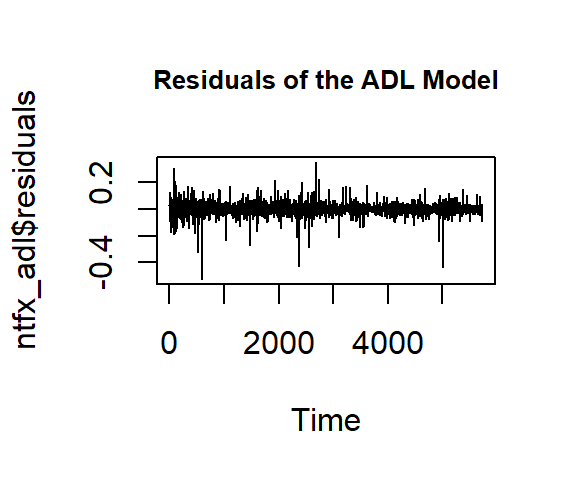

```r
# Plot residuals
plot.ts(ntfx_adl$residuals, main = "Residuals of the ADL Model",
     cex.main = 0.8,
     cex.lab = 0.7,
     cex.axis = 0.6)
```

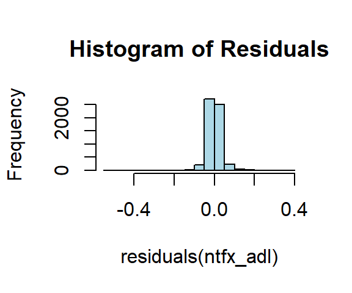

```r
hist(residuals(ntfx_adl), main = "Histogram of Residuals", col = "lightblue")
```

```r
# Test for autocorrelation in residuals (Ljung-Box Test)
Box.test(residuals(ntfx_adl), type = "Ljung-Box")
```

```
##
##  Box-Ljung test
##
## data:  residuals(ntfx_adl)
## X-squared = 9.0132e-05, df = 1, p-value = 0.9924
```

```r
# Test for heteroskedasticity (ARCH Test)
ArchTest(residuals(ntfx_adl), lags = 5)
```

```
##
##  ARCH LM-test; Null hypothesis: no ARCH effects
##
## data:  residuals(ntfx_adl)
## Chi-squared = 23.246, df = 5, p-value = 0.0003029
```

```r
# Forecast over h = 30
n_ahead <- 30
forecast_vals <- numeric(n_ahead)

# Store the most recent row of regressors
current_data <- tail(ntfx_xreg, 1)

# Get names of all needed regressors
required_vars <- names(coef(ntfx_adl))[-1]  # exclude intercept

for (i in 1:n_ahead) {
  input_data <- current_data[, required_vars, drop = FALSE]  # Ensure only relevant variables are passed
  next_forecast <- predict(ntfx_adl, newdata = input_data)   # Predict next value
  forecast_vals[i] <- next_forecast
  new_row <- current_data       # Create new row for next iteration
  new_row$Diff_Log_Close <- next_forecast   # Update Diff_Log_Close

  for (j in lags:2) {    # Update DLClose lags
    lag_name <- paste0("DLClose_Lag_", j)
    prev_lag <- paste0("DLClose_Lag_", j - 1)
    if (lag_name %in% names(new_row) && prev_lag %in% names(new_row)) {
      new_row[1, lag_name] <- current_data[1, prev_lag]
    }
  }
  if ("DLClose_Lag_1" %in% names(new_row)) {
    new_row[1, "DLClose_Lag_1"] <- next_forecast
  }
  # Update DLVol lags — assume no change (you can refine this)
  for (j in lags:2) {
    lag_name <- paste0("DLVol_Lag_", j)
    prev_lag <- paste0("DLVol_Lag_", j - 1)
    if (lag_name %in% names(new_row) && prev_lag %in% names(new_row)) {
      new_row[1, lag_name] <- current_data[1, prev_lag]
    }
  }
  if ("DLVol_Lag_1" %in% names(new_row)) {
    new_row[1, "DLVol_Lag_1"] <- current_data[1, "DLVol_Lag_1"]
  }
  # Set current_data to new_row for next iteration
  current_data <- new_row
}
print(forecast_vals)
```

```
##  [1] 0.003838740 0.002957575 0.002932073 0.002931335 0.002931314 0.002931313
##  [7] 0.002931313 0.002931313 0.002931313 0.002931313 0.002931313 0.002931313
## [13] 0.002931313 0.002931313 0.002931313 0.002931313 0.002931313 0.002931313
## [19] 0.002931313 0.002931313 0.002931313 0.002931313 0.002931313 0.002931313
## [25] 0.002931313 0.002931313 0.002931313 0.002931313 0.002931313 0.002931313
```

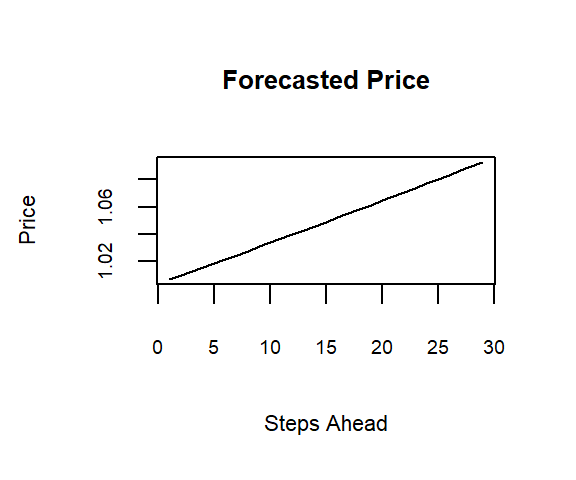

```r
# Transform Back to Price Level
last_log_price <- tail(ntfx_xts$Log_Close, 1)  # or use last actual log(close)
log_price_forecast <- cumsum(c(as.numeric(last_log_price), forecast_vals))[-1]
price_forecast <- exp(log_price_forecast)
plot(price_forecast, type = "l", main = "Forecasted Price", ylab = "Price", xlab = "Steps Ahead",
     cex.main = 0.8,
     cex.lab = 0.7,
     cex.axis = 0.6)
```